# Качество государственной медицины глазами граждан

Разведочный анализ данных обследования качества жизни населения Казахстана, 2021–2024

2026-10-06

## Исследовательский вопрос и гипотезы

### Зачем это исследование

Оценки граждан — важный источник информации о работе системы здравоохранения: ВОЗ и ОЭСР рассматривают опыт пациентов и неудовлетворённую потребность в медицинской помощи как самостоятельные показатели доступности и качества. В Казахстане удовлетворённость медицинской помощью изучалась в основном на выборках пациентов отдельных медицинских организаций. Данные общенационального обследования качества жизни позволяют перейти на уровень всего населения и связать оценки людей с характеристиками системы здравоохранения их региона.

Мы рассматриваем оценку качества не только как личное отношение человека к медицине, а как результат взаимодействия трёх уровней:

- **кто этот человек** — его социально-экономическое положение и здоровье;
- **какой у него опыт** — удалось ли получить помощь, когда она была нужна, и что помешало;
- **где он живёт** — какими ресурсами располагает здравоохранение его региона.

Концептуально мы опираемся на модель доступа к медицинской помощи Андерсена: предрасполагающие характеристики человека и его ресурсы (например, доход) вместе с потребностью в помощи (состояние здоровья) определяют использование системы и опыт взаимодействия с ней. Мы дополняем её уровнем региона: одни и те же люди могут по-разному оценивать медицину в регионах с разной обеспеченностью врачами и финансированием.

### Основной вопрос

> **В какой степени оценка качества государственных медицинских услуг связана с социально- экономическим положением граждан, их здоровьем и опытом получения медицинской помощи — и насколько эти оценки различаются в зависимости от ресурсов региональной системы здравоохранения?**

Иначе говоря, мы хотим понять, отражает ли недовольство медициной прежде всего индивидуальное положение и опыт человека или также различия в работе региональных систем здравоохранения.

### Частные вопросы

- **RQ1.** Какие социально-экономические и демографические характеристики связаны с оценкой качества государственной медицины?
- **RQ2.** Как неудовлетворённая потребность в медицинской помощи и конкретные барьеры — стоимость, очереди, отсутствие специалиста, удалённость, отсутствие лекарств — связаны с этой оценкой?
- **RQ3.** Связаны ли ресурсы региональной системы здравоохранения (финансирование, врачи, средний медперсонал) с оценками граждан после учёта их индивидуальных характеристик?
- **RQ4.** Меняет ли региональный контекст связь между личным опытом и оценкой — например, по-разному ли неудачный опыт получения помощи сказывается на оценке в регионах с разной обеспеченностью врачами?

### Гипотезы

|  | Гипотеза | Обоснование | Как проверяем |
| --- | --- | --- | --- |
| **H1** | Люди с более низким материальным положением оценивают качество государственной медицины ниже | Материальные ресурсы — фактор доступа к помощи (модель Андерсена): у менее обеспеченных меньше возможностей обойти ограничения системы, например обратиться в частную клинику | Самооценка материального положения и его изменение за год |
| **H2** | Худшая оценка собственного здоровья связана с более низкой оценкой медицины | Больше потребность в помощи — больше контактов с системой и больше шансов столкнуться с её ограничениями | Удовлетворённость своим здоровьем (Q3) |
| **H3** | Опыт неудовлетворённой потребности (не удалось получить помощь, когда она была нужна) связан с более низкой оценкой качества | Неудовлетворённая потребность — ключевой показатель доступности у ОЭСР; негативный опыт должен переноситься на оценку системы | Q18: «да» против «нет»; «не было необходимости» — отдельная категория |
| **H4** | Организационные, финансовые и территориальные барьеры связаны с оценкой качества независимо от социального положения и здоровья | Разные барьеры указывают на разные слабые места системы: кадры и очереди, стоимость, удалённость | Причины из Q19, сгруппированные по типам; самолечение — отдельно, это не барьер системы |
| **H5** | Оценки качества различаются между регионами и после учёта индивидуальных характеристик | Если различия остаются, они отражают не только состав населения, но и работу региональных систем | Доля региональной дисперсии (ICC) в пустой модели и после учёта индивидуальных факторов |
| **H6** | Связь между опытом неудовлетворённой потребности и оценкой качества зависит от ресурсной обеспеченности региона | Одинаковый негативный опыт может восприниматься по-разному там, где врачей больше или меньше | Взаимодействие Q18 × врачи на 1000 населения в многоуровневой модели |

Результаты этого исследования **не устанавливают причинно-следственных связей**: данные поперечные, и мы интерпретируем их как ассоциации. Региональные показатели — характеристики контекста, а не личные свойства респондентов: высокие расходы на здравоохранение в регионе не означают, что конкретный человек получает больше помощи.

### Что проверяет разведочный этап

Разведочный анализ готовит данные для проверки гипотез:

- **этап 1** — пригодны ли ключевые переменные (качество, доступность, неудовлетворённая потребность, барьеры) для анализа: пропуски, распределения, эффект потолка;
- **этап 2** — структура зависимой переменной;
- **этап 3** — первичная картина по H1–H2: как оценка различается по материальному положению, здоровью, типу населённого пункта, возрасту и образованию;
- **этап 4** — кто чаще сталкивается с неудовлетворённой потребностью и с какими барьерами (основа для H3–H4);
- **этап 5 и ICC** — есть ли региональные различия и как они соотносятся с ресурсами здравоохранения (H5, предпосылки для H6).

## Данные

| Уровень | Источник | Что используем |
| --- | --- | --- |
| Респондент | Обследование качества жизни населения (форма D002), 2021–2024 | Оценки медицины, здоровья, материального положения, опыт получения помощи |
| Респондент | Контрольная карточка домохозяйства (форма D008) | Образование и занятость респондента |
| Регион | БНС, «Финансово-хозяйственная деятельность организаций здравоохранения» | Текущие расходы организаций здравоохранения |
| Регион | Информационно-аналитическая система БНС «Талдау» (данные Минздрава) | Численность врачей, среднего медперсонала, населения |
| Регион | OpenStreetMap | Границы 20 регионов (с учётом областей, созданных в 2022 году) |

D002 заполняет один член домохозяйства в возрасте 15 лет и старше, около 12 тыс. респондентов в год. Шкалы удовлетворённости — от 1 до 10, код 89 означает «не применимо / затрудняюсь ответить».

**Гармонизация вопросов по годам.** Анкета менялась: в 2022–2024 годах вопросы перенумерованы, часть блоков перенесена между таблицами набора данных. Ниже — соответствие, которое мы установили по бланкам анкеты каждого года и проверили на данных (номера вопросов — по бланку 2021 года).

| Показатель | Вопрос | 2021 | 2022 | 2023–2024 |
| --- | --- | --- | --- | --- |
| Качество государственной медицины (зависимая переменная) | Q15.2 | `GR152` | `GR151` | `GR14_1` |
| Доступность государственной медицины | Q15.3 | `GR153` | `GR161` | `GR15_1` |
| Удовлетворённость своим здоровьем | Q3 | `GR3` | `GR3` | `GR3` |
| Самооценка материального положения (1–6) | Q2.1 | `GR1` | `GR1` | `GR21` |
| Изменение материального положения за год | Q2.2 | `GR2` | `GR2` | `GR23` |
| Не смог воспользоваться медицинской помощью | Q18 | `GR318` | `GR319` | `GR319` |
| Причины (можно несколько, 10 пунктов) | Q19 | `GR319_1–10` | `GR320_1–10` | `GR320_1–10` |

**Ограничения:**

- **Данные датасета синтетические.** Связи между переменными в них ослаблены — особенно между вопросами, которые лежат в разных таблицах набора данных (например, оценка качества и опыт получения помощи). Поэтому ряд связей, ожидаемых по теории, может проявляться слабее, чем в реальных данных.
- **Весов нет.** Все доли и средние — выборочные, а не оценки для населения.
- **В данных 2022–2024 годов есть «респонденты» младше 15 лет** (в том числе с возрастом −1), хотя анкета заполняется лицами 15+. Мы их исключаем.
- **Вопрос о стоимости государственной медицины задавался только в 2021 году**, поэтому в анализе его нет.

## Подготовка данных

Анализ строится на объединённом датасете, который собирает скрипт `00_build_dataset.Rmd`: в нём вопросы сведены по годам по таблице выше, а к каждому респонденту присоединены его строка из контрольной карточки D008 и показатели региона. При сборке проверяются наличие всех нужных колонок в каждом году, допустимость кодов ответов, уникальность и совпадение идентификаторов домохозяйств между таблицами. Здесь коды ответов и связи проверяются повторно, а также сопоставление всех регионов. Если хотя бы одна проверка не проходит, отчёт не собирается.

```r
# Объединённый датасет: одна строка — респондент D002 в одном году, вопросы уже сведены
# по годам, строка респондента из D008 присоединена (столбцы d008_*).
dataset <- readRDS(dataset_file)

raw <- dataset |>
  transmute(year, NOMER, NOMP, TE, K, POL, age,
            q_raw = as.character(quality_state), acc_raw = as.character(access_state),
            health_raw = as.character(sat_health),
            wealth_raw = as.character(wealth), wealth_change_raw = as.character(wealth_change),
            unmet_raw = as.character(unmet),
            across(num_range("unmet_reason_", 1:10), \(x) x %in% 1L,
                   .names = "{sub('unmet_reason_', 'r', .col)}"),
            UROV = d008_UROV, STATUS = d008_STATUS, in_d008 = !is.na(d008_RODSTVO))

# Повторная проверка кодов ответов
check_codes(raw$q_raw, c(1:10, 89), "Q15.2")
check_codes(raw$acc_raw, c(1:10, 89), "Q15.3")
check_codes(raw$health_raw, c(1:10, 89), "Q3")
check_codes(raw$wealth_raw, 1:6, "Q2.1")
check_codes(raw$wealth_change_raw, 1:3, "Q2.2")
check_codes(raw$unmet_raw, 1:3, "Q18")
stopifnot(all(years %in% raw$year), !anyDuplicated(raw[c("year", "NOMER")]))

# Проверки связей
stopifnot(all(raw$TE %in% names(region_names)),
          # причины называют только те, кто не смог получить помощь
          sum(raw$unmet_raw != "1" & rowSums(raw[paste0("r", 1:10)]) > 0) == 0)

tibble(Год = years,
       `Респондентов D002` = map_int(years, \(y) sum(raw$year == y)),
       `Найдены в D008` = map_chr(years, \(y) percent(mean(raw$in_d008[raw$year == y]), 0.1)),
       `Регионов` = map_int(years, \(y) n_distinct(raw$TE[raw$year == y])),
       `Младше 15 лет (в т.ч. возраст −1)` = map_int(years, \(y) sum(raw$year == y & raw$age < 15))) |>
  knitr::kable()
```

| Год | Респондентов D002 | Найдены в D008 | Регионов | Младше 15 лет (в т.ч. возраст −1) |
| --- | --- | --- | --- | --- |
| 2021 | 11953 | 100.0% | 17 | 0 |
| 2022 | 11934 | 100.0% | 20 | 631 |
| 2023 | 11953 | 100.0% | 20 | 656 |
| 2024 | 11931 | 100.0% | 20 | 685 |

Аналитическая выборка — респонденты 15 лет и старше. Возраст берём из основного блока анкеты D002: он согласован с годом рождения в D008 (в 2021 году года рождения в D008 нет).

```r
d <- raw |>
  filter(age >= 15) |>
  mutate(
    year_f = factor(year),
    region = factor(TE),
    area = factor(if_else(K == "2", "Село", "Город"), c("Город", "Село")),
    sex = factor(if_else(POL == "2", "Женщины", "Мужчины"), c("Мужчины", "Женщины")),
    q = if_else(q_raw == "89", NA_real_, as.numeric(q_raw)),
    acc = if_else(acc_raw == "89", NA_real_, as.numeric(acc_raw)),
    health = if_else(health_raw == "89", NA_real_, as.numeric(health_raw)),
    q_band = cut(q, c(0, 3, 7, 10), c("1–3 не удовлетворён", "4–7 частично", "8–10 удовлетворён")),
    health_g = cut(health, c(0, 4, 6, 7, 8, 10), c("1–4", "5–6", "7", "8", "9–10")),
    wealth = factor(c("1" = "1–2 ниже среднего", "2" = "1–2 ниже среднего", "3" = "3 средний",
                      "4" = "4 несколько выше", "5" = "5–6 состоятельные",
                      "6" = "5–6 состоятельные")[wealth_raw],
                    c("1–2 ниже среднего", "3 средний", "4 несколько выше", "5–6 состоятельные")),
    wealth_change = factor(c("1" = "Не изменилось", "2" = "Улучшилось", "3" = "Ухудшилось")[wealth_change_raw],
                           c("Ухудшилось", "Не изменилось", "Улучшилось")),
    age_g = cut(age, c(14, 29, 44, 59, Inf), c("15–29", "30–44", "45–59", "60+")),
    educ = factor(case_when(UROV %in% c("5", "6") ~ "Высшее",
                            UROV == "4" ~ "Среднее / ТиПО",
                            UROV %in% c("1", "2", "3", "7") ~ "Ниже среднего"),
                  c("Ниже среднего", "Среднее / ТиПО", "Высшее")),
    employ = factor(case_when(STATUS %in% c("1", "2") ~ "Занят",
                              STATUS == "3" ~ "Безработный",
                              STATUS == "4" ~ "Пенсионер",
                              STATUS == "5" ~ "Учащийся",
                              STATUS %in% c("6", "7", "8") ~ "Прочие неактивные"),
                    c("Занят", "Безработный", "Учащийся", "Пенсионер", "Прочие неактивные")),
    unmet = factor(c("1" = "Да", "2" = "Нет", "3" = "Не было необходимости")[unmet_raw],
                   c("Да", "Нет", "Не было необходимости")),
    unmet_yes = if_else(unmet == "Не было необходимости", NA, unmet == "Да")
  )

# Проверки перекодировок: пропуски появляются только там, где в исходных данных 89 или пусто
stopifnot(sum(is.na(d$q)) == sum(d$q_raw == "89"),
          sum(is.na(d$acc)) == sum(d$acc_raw == "89"),
          all(!is.na(d$wealth)), all(!is.na(d$wealth_change)), all(!is.na(d$unmet)),
          all(!is.na(d$age_g)))

cat("Аналитическая выборка:", nrow(d), "респондентов 15+ из", nrow(raw), "\n")
```

```
## Аналитическая выборка: 45799 респондентов 15+ из 47771
```

## Этап 1. Проверка распределений

### 1.1. Пропуски и «не применимо / затрудняюсь»

Для шкал 1–10 код 89 означает «не применимо / затрудняюсь ответить». Пустых значений в вопросах D002 нет; пропуски в образовании и занятости — незаполненные поля в D008.

```r
miss_vars <- tribble(
  ~var,         ~label,                                   ~raw_col,
  "q",          "Q15.2 Качество гос. медицины",          "q_raw",
  "acc",        "Q15.3 Доступность гос. медицины",       "acc_raw",
  "health",     "Q3 Удовлетворённость здоровьем",        "health_raw",
  "wealth",     "Q2.1 Материальное положение",            "wealth_raw",
  "wealth_change", "Q2.2 Изменение положения",            "wealth_change_raw",
  "unmet",      "Q18 Не смог получить помощь",           "unmet_raw",
  "educ",       "Образование (D008)",                    "UROV",
  "employ",     "Занятость (D008)",                       "STATUS"
)

miss_vars |>
  pmap(\(var, label, raw_col) {
    d |>
      group_by(year) |>
      summarise(value = sprintf("%.1f%% / %.1f%%",
                                100 * mean(.data[[raw_col]] %in% "89"),
                                100 * mean(is.na(.data[[var]]) & !(.data[[raw_col]] %in% "89"))),
                .groups = "drop") |>
      mutate(Показатель = label)
  }) |>
  list_rbind() |>
  pivot_wider(names_from = year, values_from = value) |>
  knitr::kable(caption = "Доля «89 — не применимо / затрудняюсь» / доля пустых значений, по годам")
```

Доля «89 — не применимо / затрудняюсь» / доля пустых значений, по годам

| Показатель | 2021 | 2022 | 2023 | 2024 |
| --- | --- | --- | --- | --- |
| Q15.2 Качество гос. медицины | 2.6% / 0.0% | 3.5% / 0.0% | 2.4% / 0.0% | 2.8% / 0.0% |
| Q15.3 Доступность гос. медицины | 2.5% / 0.0% | 2.6% / 0.0% | 2.7% / 0.0% | 3.0% / 0.0% |
| Q3 Удовлетворённость здоровьем | 0.3% / 0.0% | 0.2% / 0.0% | 0.1% / 0.0% | 0.4% / 0.0% |
| Q2.1 Материальное положение | 0.0% / 0.0% | 0.0% / 0.0% | 0.0% / 0.0% | 0.0% / 0.0% |
| Q2.2 Изменение положения | 0.0% / 0.0% | 0.0% / 0.0% | 0.0% / 0.0% | 0.0% / 0.0% |
| Q18 Не смог получить помощь | 0.0% / 0.0% | 0.0% / 0.0% | 0.0% / 0.0% | 0.0% / 0.0% |
| Образование (D008) | 0.0% / 0.3% | 0.0% / 0.0% | 0.0% / 0.0% | 0.0% / 0.0% |
| Занятость (D008) | 0.0% / 14.3% | 0.0% / 5.8% | 0.0% / 1.1% | 0.0% / 0.9% |

**Результат.** Пропусков почти нет. «Не применимо / затрудняюсь» по Q15.2 — 2.4–3.5%, по Q15.3 — 2.5–3.0%, по здоровью — до 0.4%; материальное положение и Q18 заполнены у всех. Единственный заметный пробел — занятость в 2021 году (не заполнена у 14.3% респондентов, в 2022-м — у 5.8%); при анализе занятости мы это учитываем.

### 1.2. Распределение Q15.2 (качество) и Q15.3 (доступность)

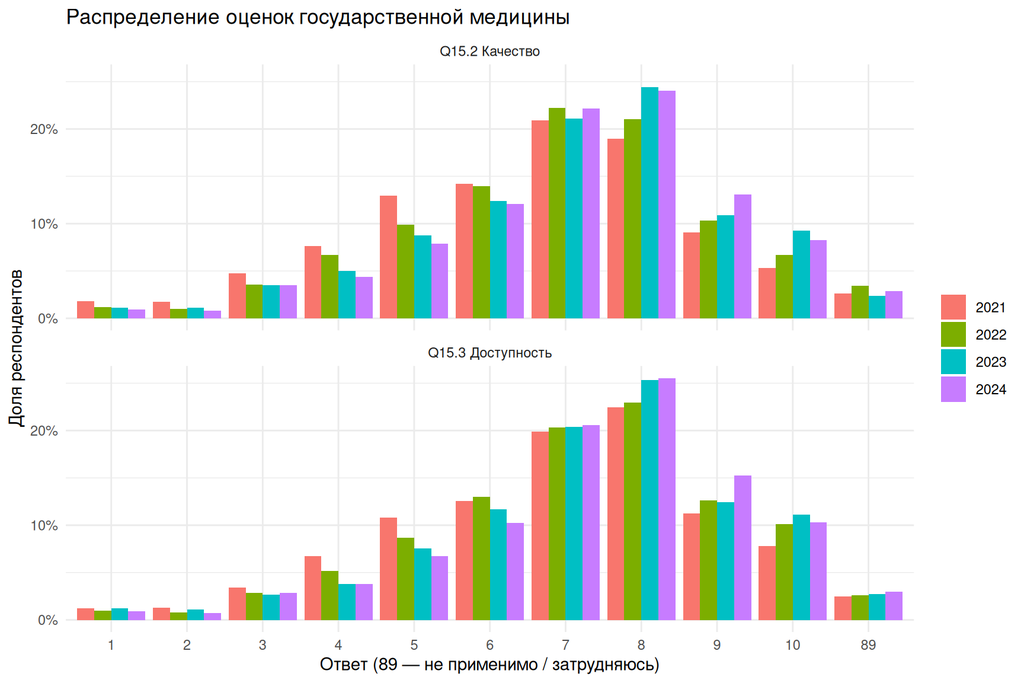

```r
d |>
  select(year, `Q15.2 Качество` = q_raw, `Q15.3 Доступность` = acc_raw) |>
  pivot_longer(-year, names_to = "item", values_to = "value") |>
  mutate(value = factor(if_else(value == "89", "89", value), c(1:10, "89"))) |>
  count(year, item, value) |>
  group_by(year, item) |>
  mutate(share = n / sum(n)) |>
  ggplot(aes(value, share, fill = factor(year))) +
  geom_col(position = "dodge") +
  facet_wrap(~item, ncol = 1) +
  scale_y_continuous(labels = lab_pct) +
  labs(x = "Ответ (89 — не применимо / затрудняюсь)", y = "Доля респондентов", fill = NULL,
       title = "Распределение оценок государственной медицины")
```

```r
d |>
  group_by(year) |>
  summarise(`Спирмен Q15.2–Q15.3` = cor(q, acc, method = "spearman", use = "complete.obs"),
            `Q15.2 = Q15.3 (одинаковый балл)` = mean(q == acc, na.rm = TRUE)) |>
  knitr::kable(digits = 2)
```

| year | Спирмен Q15.2–Q15.3 | Q15.2 = Q15.3 (одинаковый балл) |
| --- | --- | --- |
| 2021 | 0.78 | 0.67 |
| 2022 | 0.77 | 0.61 |
| 2023 | 0.80 | 0.68 |
| 2024 | 0.83 | 0.71 |

**Результат.** Оценки качества и доступности распределены почти одинаково и очень сильно связаны: ранговая корреляция 0.77–0.83, а в 61–71% случаев респондент ставит обоим вопросам **один и тот же балл**. По сути это одно измерение. Поэтому мы не используем доступность как объясняющую переменную в основной модели качества: она объясняла бы оценку почти тем же самым ответом.

### 1.3. Распределение Q18 (неудовлетворённая потребность)

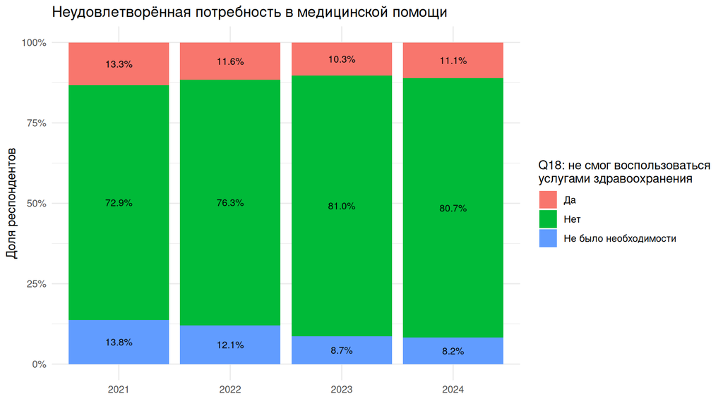

```r
d |>
  count(year, unmet) |>
  group_by(year) |>
  mutate(share = n / sum(n)) |>
  ggplot(aes(factor(year), share, fill = unmet)) +
  geom_col() +
  geom_text(aes(label = percent(share, 0.1)), position = position_stack(vjust = 0.5), size = 3) +
  scale_y_continuous(labels = lab_pct) +
  labs(x = NULL, y = "Доля респондентов", fill = "Q18: не смог воспользоваться\nуслугами здравоохранения",
       title = "Неудовлетворённая потребность в медицинской помощи")
```

**Результат.** Не смогли воспользоваться медпомощью 10–13% респондентов в год (13.3% в 2021 году, 10.3–11.6% в 2022–2024). Доля ответивших «не было необходимости» заметно снизилась — с 13.8% в 2021 году до 8.2% в 2024-м. Среди тех, кому помощь была нужна, неудовлетворённая потребность составляет 13.0% за все годы (15.4% в 2021 году, 11–12% в 2023–2024).

### 1.4. Частота барьеров Q19

Q19 задаётся только тем, кто ответил «да» на Q18; можно отметить несколько причин. Доли считаются среди ответивших «да» на Q18.

```r
reason_labels <- tribble(
  ~r,     ~reason,                                  ~type,
  "r1",   "Самолечение",                            "Выбор респондента",
  "r2",   "Решил, что выздоровею сам",              "Выбор респондента",
  "r3",   "Высокая стоимость услуг",                "Финансовый барьер",
  "r4",   "Дорогие лекарства",                      "Финансовый барьер",
  "r5",   "Большие очереди",                        "Организационный барьер",
  "r6",   "Нет специалиста",                        "Организационный барьер",
  "r7",   "Далеко / нет возможности доехать",       "Территориальный барьер",
  "r8",   "Нет лекарств",                           "Организационный барьер",
  "r9",   "Плохое обслуживание / недоверие",        "Качество и доверие",
  "r10",  "Другие причины",                         "Прочее"
)

unmet_d <- filter(d, unmet == "Да")

barriers <- unmet_d |>
  select(year, all_of(reason_labels$r)) |>
  pivot_longer(-year, names_to = "r", values_to = "chosen") |>
  group_by(year, r) |>
  summarise(share = mean(chosen), .groups = "drop") |>
  left_join(reason_labels, by = "r")

barriers |>
  select(Причина = reason, Тип = type, year, share) |>
  pivot_wider(names_from = year, values_from = share) |>
  mutate(across(where(is.numeric), \(x) percent(x, 0.1))) |>
  knitr::kable(caption = "Доля отметивших причину среди не сумевших получить помощь")
```

Доля отметивших причину среди не сумевших получить помощь

| Причина | Тип | 2021 | 2022 | 2023 | 2024 |
| --- | --- | --- | --- | --- | --- |
| Самолечение | Выбор респондента | 38.4% | 37.1% | 45.4% | 46.2% |
| Другие причины | Прочее | 3.6% | 4.3% | 2.8% | 5.0% |
| Решил, что выздоровею сам | Выбор респондента | 9.4% | 13.0% | 18.5% | 20.1% |
| Высокая стоимость услуг | Финансовый барьер | 11.0% | 15.0% | 17.9% | 14.3% |
| Дорогие лекарства | Финансовый барьер | 11.7% | 17.0% | 22.0% | 19.5% |
| Большие очереди | Организационный барьер | 16.2% | 22.7% | 29.3% | 25.3% |
| Нет специалиста | Организационный барьер | 22.7% | 27.2% | 28.5% | 24.6% |
| Далеко / нет возможности доехать | Территориальный барьер | 4.7% | 6.0% | 2.1% | 5.0% |
| Нет лекарств | Организационный барьер | 3.0% | 2.7% | 1.7% | 2.9% |
| Плохое обслуживание / недоверие | Качество и доверие | 5.6% | 6.2% | 8.5% | 8.3% |

```r
unmet_d |>
  mutate(n_reasons = rowSums(pick(all_of(reason_labels$r)))) |>
  group_by(year) |>
  summarise(`Не сумели получить помощь` = n(),
            `Не назвали ни одной причины` = percent(mean(n_reasons == 0), 0.1),
            `Среднее число причин` = round(mean(n_reasons), 2)) |>
  knitr::kable()
```

| year | Не сумели получить помощь | Не назвали ни одной причины | Среднее число причин |
| --- | --- | --- | --- |
| 2021 | 1589 | 7.7% | 1.26 |
| 2022 | 1311 | 11.1% | 1.51 |
| 2023 | 1161 | 7.2% | 1.77 |
| 2024 | 1251 | 7.0% | 1.71 |

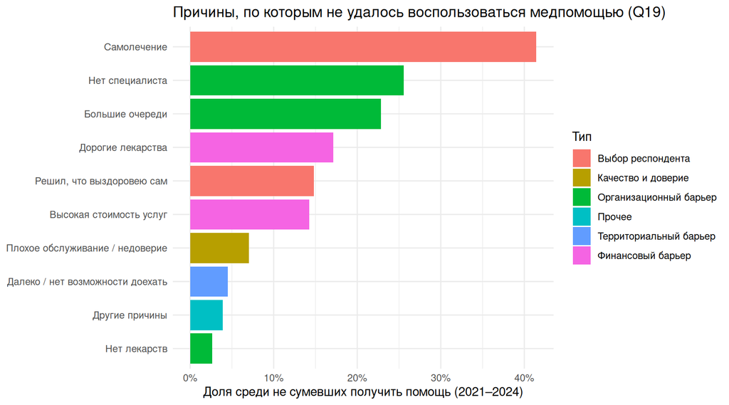

```r
barriers |>
  group_by(reason, type) |>
  summarise(share = weighted.mean(share, table(unmet_d$year)[as.character(year)]), .groups = "drop") |>
  ggplot(aes(share, fct_reorder(reason, share), fill = type)) +
  geom_col() +
  scale_x_continuous(labels = lab_pct) +
  labs(x = "Доля среди не сумевших получить помощь (2021–2024)", y = NULL, fill = "Тип",
       title = "Причины, по которым не удалось воспользоваться медпомощью (Q19)")
```

**Результат.**

- Самая частая причина — **самолечение** (37–46%) — не барьер системы, а решение респондента; вместе с «решил, что выздоровею сам» (9–20%) это заметная часть всех ответов. Мы выделяем эти причины в отдельную группу и не смешиваем их с барьерами системы.
- Среди барьеров системы лидируют **организационные**: нет специалиста (23–29%) и очереди (16–29%). **Финансовые** — дорогие лекарства (12–22%) и стоимость услуг (11–18%).
- **Территориальные** (2–6%) и **отсутствие лекарств** (2–3%) встречаются редко — в моделях оценки для них будут неточными.
- Доли почти всех причин растут от 2021 к 2023 году отчасти потому, что растёт среднее число отмеченных причин (1.26 → 1.77). Сравнивать годы по этим долям нужно осторожно.

### 1.5. Концентрация Q15.2 на верхних значениях

Проверяем «эффект потолка»: сколько ответов приходится на верх шкалы и насколько распределение скошено.

```r
skewness <- function(x) {
  x <- na.omit(x)
  mean((x - mean(x))^3) / sd(x)^3
}

d |>
  group_by(year) |>
  summarise(`Мода` = as.integer(names(which.max(table(q)))),
            `Доля 10` = mean(q == 10, na.rm = TRUE),
            `Доля 9–10` = mean(q >= 9, na.rm = TRUE),
            `Доля 8–10` = mean(q >= 8, na.rm = TRUE),
            `Доля 1–3` = mean(q <= 3, na.rm = TRUE),
            `Асимметрия` = skewness(q)) |>
  mutate(across(starts_with("Доля"), \(x) percent(x, 0.1))) |>
  knitr::kable(digits = 2)
```

| year | Мода | Доля 10 | Доля 9–10 | Доля 8–10 | Доля 1–3 | Асимметрия |
| --- | --- | --- | --- | --- | --- | --- |
| 2021 | 7 | 5.5% | 14.7% | 34.2% | 8.5% | -0.49 |
| 2022 | 7 | 6.9% | 17.6% | 39.4% | 6.0% | -0.57 |
| 2023 | 8 | 9.5% | 20.7% | 45.7% | 5.9% | -0.69 |
| 2024 | 8 | 8.5% | 21.9% | 46.7% | 5.4% | -0.74 |

**Результат.** Выраженного «эффекта потолка» нет: высшую оценку 10 ставят 5.5–9.5%, мода — 7 в 2021–2022 годах и 8 в 2023–2024. Но распределение смещено к верхней части шкалы, и этот сдвиг усиливается: доля оценок 8–10 выросла с 34% до 47%, отрицательная асимметрия — с −0.49 до −0.74. Для порядковой модели такое распределение не проблема; линейная модель годится как проверка устойчивости.

## Этап 2. Структура оценки качества (Q15.2)

```r
q_stats <- function(x) {
  x <- na.omit(x)
  tibble(n = length(x), `Среднее` = mean(x), `Ст. откл.` = sd(x), `Медиана` = median(x),
         Q1 = quantile(x, 0.25, names = FALSE), Q3 = quantile(x, 0.75, names = FALSE),
         `1–3` = percent(mean(x <= 3), 0.1), `4–7` = percent(mean(x >= 4 & x <= 7), 0.1),
         `8–10` = percent(mean(x >= 8), 0.1))
}

bind_rows(d |> group_by(Год = as.character(year)) |> reframe(q_stats(q)),
          d |> reframe(q_stats(q)) |> mutate(Год = "2021–2024")) |>
  knitr::kable(digits = 2)
```

| Год | n | Среднее | Ст. откл. | Медиана | Q1 | Q3 | 1–3 | 4–7 | 8–10 |
| --- | --- | --- | --- | --- | --- | --- | --- | --- | --- |
| 2021 | 11641 | 6.50 | 2.02 | 7 | 5 | 8 | 8.5% | 57.2% | 34.2% |
| 2022 | 10911 | 6.81 | 1.92 | 7 | 6 | 8 | 6.0% | 54.6% | 39.4% |
| 2023 | 11029 | 7.03 | 1.94 | 7 | 6 | 8 | 5.9% | 48.4% | 45.7% |
| 2024 | 10926 | 7.11 | 1.88 | 7 | 6 | 8 | 5.4% | 47.9% | 46.7% |
| 2021–2024 | 44507 | 6.86 | 1.96 | 7 | 6 | 8 | 6.5% | 52.1% | 41.4% |

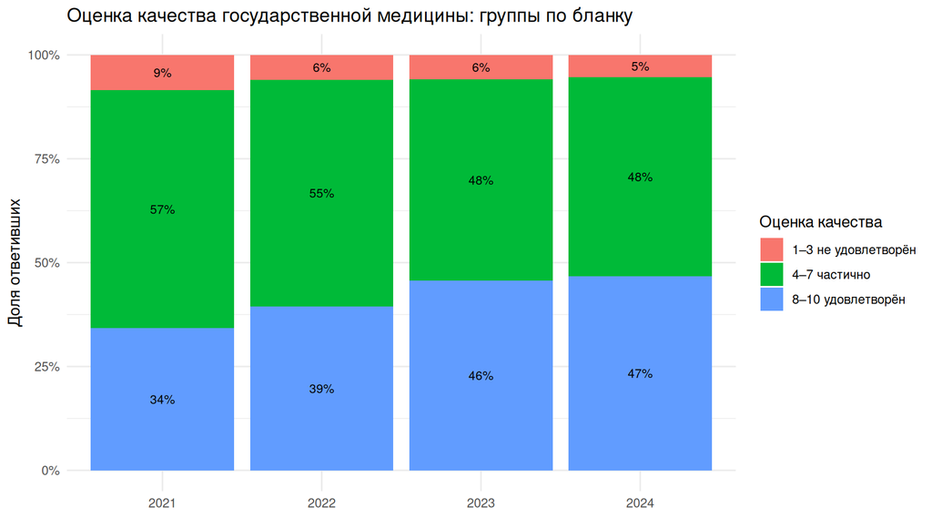

```r
d |>
  filter(!is.na(q_band)) |>
  count(year, q_band) |>
  group_by(year) |>
  mutate(share = n / sum(n)) |>
  ggplot(aes(factor(year), share, fill = q_band)) +
  geom_col() +
  geom_text(aes(label = percent(share, 1)), position = position_stack(vjust = 0.5), size = 3) +
  scale_y_continuous(labels = lab_pct) +
  labs(x = NULL, y = "Доля ответивших", fill = "Оценка качества",
       title = "Оценка качества государственной медицины: группы по бланку")
```

**Результат.** Средняя оценка — 6.86, медиана 7, половина ответов между 6 и 8. «Удовлетворены» (8–10) — 41%, «частично» (4–7) — 52%, «не удовлетворены» (1–3) — 6.5%. Оценки **растут от года к году** (среднее 6.50 → 7.11, доля 8–10 — 34% → 47%), поэтому в моделях обязательно нужны эффекты года, иначе годовой тренд смешается с различиями между группами.

## Этап 3. Карта социальных различий

Сравнение Q15.2 по материальному положению, здоровью, типу населённого пункта, возрасту и образованию. Все годы объединены; устойчивость по годам проверяется таблицей средних. Это описание структуры данных, а не проверка гипотез.

```r
dims <- c(wealth = "Материальное положение (Q2.1)", health_g = "Удовлетворённость здоровьем (Q3)",
          area = "Тип населённого пункта", age_g = "Возраст", educ = "Образование")

group_q <- map(names(dims), \(v) {
  d |>
    filter(!is.na(q), !is.na(.data[[v]])) |>
    group_by(level = .data[[v]]) |>
    summarise(n = n(), mean = mean(q), se = sd(q) / sqrt(n()),
              low = mean(q <= 3), high = mean(q >= 8), .groups = "drop") |>
    mutate(dim = dims[v], level = as.character(level))
}) |>
  list_rbind() |>
  mutate(dim = factor(dim, dims))
```

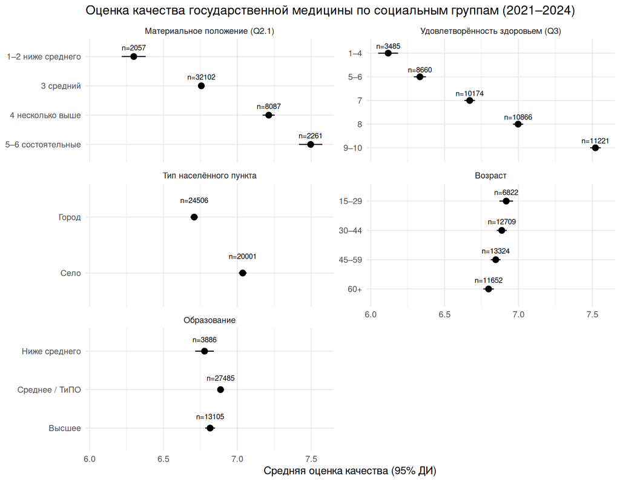

```r
group_q |>
  mutate(level = fct_inorder(level)) |>
  ggplot(aes(mean, fct_rev(level))) +
  geom_pointrange(aes(xmin = mean - 1.96 * se, xmax = mean + 1.96 * se)) +
  geom_text(aes(label = paste0("n=", n)), nudge_y = 0.3, size = 2.7) +
  facet_wrap(~dim, scales = "free_y", ncol = 2) +
  labs(x = "Средняя оценка качества (95% ДИ)", y = NULL,
       title = "Оценка качества государственной медицины по социальным группам (2021–2024)")
```

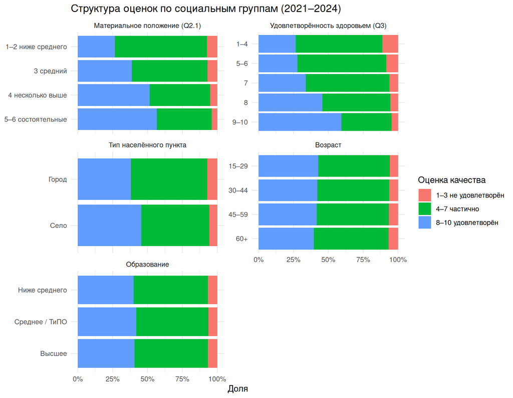

```r
map(names(dims), \(v) {
  d |>
    filter(!is.na(q_band), !is.na(.data[[v]])) |>
    count(level = .data[[v]], q_band) |>            # фактор: порядок уровней сохраняется
    group_by(level) |>
    mutate(share = n / sum(n), dim = dims[v], level = as.character(level)) |>
    ungroup()
}) |>
  list_rbind() |>
  mutate(dim = factor(dim, dims), level = fct_inorder(level)) |>
  ggplot(aes(share, fct_rev(level), fill = q_band)) +
  geom_col() +
  facet_wrap(~dim, scales = "free_y", ncol = 2) +
  scale_x_continuous(labels = lab_pct) +
  labs(x = "Доля", y = NULL, fill = "Оценка качества",
       title = "Структура оценок по социальным группам (2021–2024)")
```

Устойчивость по годам: средняя оценка в каждой группе по годам. Уровень растёт от года к году у всех групп, поэтому важнее, сохраняется ли порядок групп.

```r
map(names(dims), \(v) {
  d |>
    filter(!is.na(q), !is.na(.data[[v]])) |>
    group_by(Измерение = dims[v], Группа = .data[[v]], year) |>
    summarise(mean = mean(q), .groups = "drop") |>
    mutate(Группа = as.character(Группа))
}) |>
  list_rbind() |>
  pivot_wider(names_from = year, values_from = mean) |>
  knitr::kable(digits = 2)
```

| Измерение | Группа | 2021 | 2022 | 2023 | 2024 |
| --- | --- | --- | --- | --- | --- |
| Материальное положение (Q2.1) | 1–2 ниже среднего | 6.18 | 6.81 | 6.30 | 6.76 |
| Материальное положение (Q2.1) | 3 средний | 6.49 | 6.77 | 6.84 | 6.90 |
| Материальное положение (Q2.1) | 4 несколько выше | 6.64 | 6.95 | 7.52 | 7.63 |
| Материальное положение (Q2.1) | 5–6 состоятельные | 6.86 | 7.11 | 7.93 | 8.00 |
| Удовлетворённость здоровьем (Q3) | 1–4 | 5.73 | 6.16 | 6.43 | 6.30 |
| Удовлетворённость здоровьем (Q3) | 5–6 | 6.04 | 6.36 | 6.47 | 6.53 |
| Удовлетворённость здоровьем (Q3) | 7 | 6.30 | 6.64 | 6.83 | 6.85 |
| Удовлетворённость здоровьем (Q3) | 8 | 6.67 | 6.97 | 7.17 | 7.20 |
| Удовлетворённость здоровьем (Q3) | 9–10 | 7.18 | 7.40 | 7.66 | 7.84 |
| Тип населённого пункта | Город | 6.33 | 6.70 | 6.88 | 6.96 |
| Тип населённого пункта | Село | 6.72 | 6.94 | 7.21 | 7.29 |
| Возраст | 15–29 | 6.64 | 6.91 | 7.05 | 7.15 |
| Возраст | 30–44 | 6.50 | 6.87 | 7.11 | 7.11 |
| Возраст | 45–59 | 6.47 | 6.77 | 7.02 | 7.11 |
| Возраст | 60+ | 6.44 | 6.74 | 6.93 | 7.08 |
| Образование | Ниже среднего | 6.49 | 6.80 | 6.95 | 7.30 |
| Образование | Среднее / ТиПО | 6.52 | 6.83 | 7.05 | 7.13 |
| Образование | Высшее | 6.46 | 6.78 | 6.99 | 7.01 |

**Результат.**

- **Удовлетворённость здоровьем** — самый сильный и устойчивый градиент: от 5.7–6.4 балла у недовольных здоровьем (1–4) до 7.2–7.8 у довольных (9–10), одинаково во все годы (ранговая корреляция 0.24–0.31). Оба вопроса — удовлетворённость в одной анкете, поэтому часть связи может быть общим «фоном» ответов.
- **Материальное положение**: выше оценивают «несколько выше среднего» и «состоятельные». Но здесь два важных уточнения:
  - группа «ниже среднего» на 70% состоит из респондентов 2021 года (в 2021 году к ней отнесли себя 12.6% против 1–2% в другие годы), а 2021 год в целом оценивает медицину ниже. Поэтому по объединённым данным её оценка занижена годом; сравнивать нужно внутри года;
  - в 2021–2022 годах связь оценки с достатком почти нулевая (ρ = 0.04–0.08), а в 2023–2024 — около 0.20. Именно в 2023 году вопрос о достатке перенесли в ту же таблицу набора данных, где лежит оценка качества. Мы считаем это особенностью синтетических данных: связи внутри одной таблицы сохранены лучше, чем между таблицами.
- **Село** оценивает медицину выше города во все годы — на 0.24–0.39 балла (7.04 против 6.71 за все годы).
- **Возраст и образование** почти не различаются: разница средних не больше 0.3 балла и без устойчивого порядка по годам.

## Этап 4. Неудовлетворённая потребность

Мы используем бинарную переменную: 1 — была ситуация, когда помощь получить не удалось; 0 — такой ситуации не было. Ответ «не было необходимости» — отдельная категория, её нельзя приравнивать к отсутствию проблемы. Поэтому P(UnmetNeed = 1) считается **среди тех, кому помощь была нужна** (ответы «да» и «нет»), а доля «не было необходимости» показана отдельно.

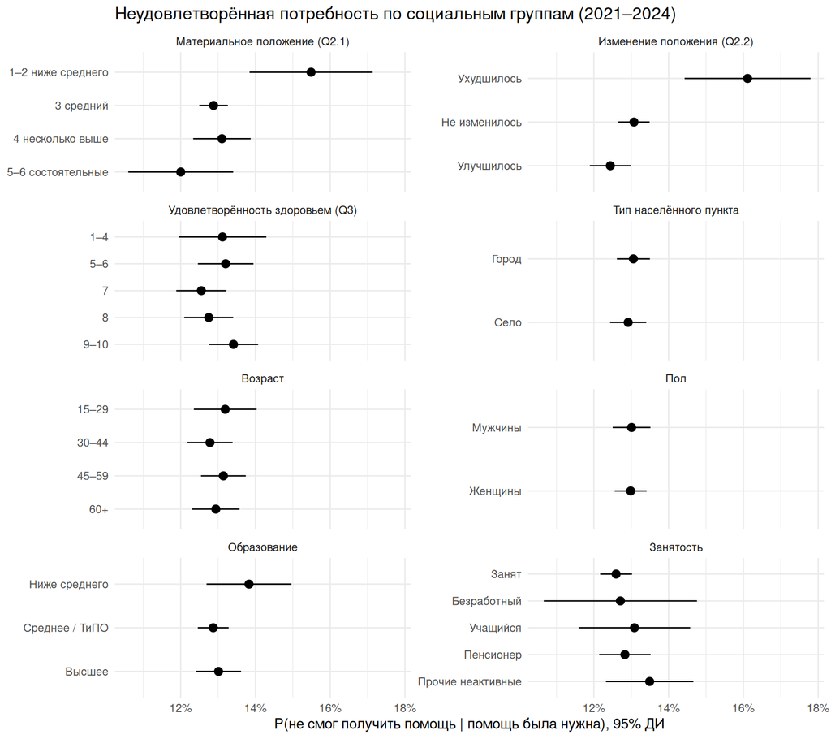

```r
dims4 <- c(wealth = "Материальное положение (Q2.1)", wealth_change = "Изменение положения (Q2.2)",
           health_g = "Удовлетворённость здоровьем (Q3)", area = "Тип населённого пункта",
           age_g = "Возраст", sex = "Пол", educ = "Образование", employ = "Занятость")

unmet_groups <- map(names(dims4), \(v) {
  d |>
    filter(!is.na(.data[[v]])) |>
    group_by(level = .data[[v]]) |>                 # фактор: порядок уровней сохраняется
    summarise(n_need = sum(!is.na(unmet_yes)),
              p = mean(unmet_yes, na.rm = TRUE),
              se = sqrt(p * (1 - p) / n_need),
              no_need = mean(unmet == "Не было необходимости"), .groups = "drop") |>
    mutate(dim = dims4[v], level = as.character(level))
}) |>
  list_rbind() |>
  mutate(dim = factor(dim, dims4))

unmet_groups |>
  mutate(level = fct_inorder(level)) |>
  ggplot(aes(p, fct_rev(level))) +
  geom_pointrange(aes(xmin = p - 1.96 * se, xmax = p + 1.96 * se)) +
  facet_wrap(~dim, scales = "free_y", ncol = 2) +
  scale_x_continuous(labels = lab_pct) +
  labs(x = "P(не смог получить помощь | помощь была нужна), 95% ДИ", y = NULL,
       title = "Неудовлетворённая потребность по социальным группам (2021–2024)")
```

```r
unmet_groups |>
  transmute(Измерение = dim, Группа = level, `Нуждались` = n_need,
            `P(unmet = 1)` = percent(p, 0.1), `«Не было необходимости»` = percent(no_need, 0.1)) |>
  knitr::kable()
```

| Измерение | Группа | Нуждались | P(unmet = 1) | «Не было необходимости» |
| --- | --- | --- | --- | --- |
| Материальное положение (Q2.1) | 1–2 ниже среднего | 1853 | 15.5% | 12.2% |
| Материальное положение (Q2.1) | 3 средний | 29574 | 12.9% | 10.6% |
| Материальное положение (Q2.1) | 4 несколько выше | 7395 | 13.1% | 10.8% |
| Материальное положение (Q2.1) | 5–6 состоятельные | 2058 | 12.0% | 10.6% |
| Изменение положения (Q2.2) | Ухудшилось | 1831 | 16.1% | 10.5% |
| Изменение положения (Q2.2) | Не изменилось | 25158 | 13.1% | 10.5% |
| Изменение положения (Q2.2) | Улучшилось | 13891 | 12.4% | 11.2% |
| Удовлетворённость здоровьем (Q3) | 1–4 | 3194 | 13.1% | 10.8% |
| Удовлетворённость здоровьем (Q3) | 5–6 | 7975 | 13.2% | 10.4% |
| Удовлетворённость здоровьем (Q3) | 7 | 9393 | 12.6% | 10.4% |
| Удовлетворённость здоровьем (Q3) | 8 | 9968 | 12.8% | 10.8% |
| Удовлетворённость здоровьем (Q3) | 9–10 | 10252 | 13.4% | 11.2% |
| Тип населённого пункта | Город | 22401 | 13.1% | 10.9% |
| Тип населённого пункта | Село | 18479 | 12.9% | 10.6% |
| Возраст | 15–29 | 6254 | 13.2% | 11.3% |
| Возраст | 30–44 | 11656 | 12.8% | 11.1% |
| Возраст | 45–59 | 12190 | 13.1% | 10.8% |
| Возраст | 60+ | 10780 | 12.9% | 10.1% |
| Пол | Мужчины | 17112 | 13.0% | 10.6% |
| Пол | Женщины | 23768 | 13.0% | 10.8% |
| Образование | Ниже среднего | 3551 | 13.8% | 11.4% |
| Образование | Среднее / ТиПО | 25266 | 12.9% | 10.7% |
| Образование | Высшее | 12034 | 13.0% | 10.6% |
| Занятость | Занят | 23352 | 12.6% | 10.5% |
| Занятость | Безработный | 1015 | 12.7% | 11.5% |
| Занятость | Учащийся | 1964 | 13.1% | 10.8% |
| Занятость | Пенсионер | 9072 | 12.8% | 9.8% |
| Занятость | Прочие неактивные | 3276 | 13.5% | 11.9% |

Проверка с учётом года: логистическая регрессия P(unmet = 1) на материальное положение и его изменение с эффектами года (среди нуждавшихся в помощи).

```r
glm(unmet_yes ~ wealth + wealth_change + year_f, data = d, family = binomial) |>
  broom::tidy(conf.int = TRUE, exponentiate = TRUE) |>
  filter(term != "(Intercept)") |>
  select(Переменная = term, OR = estimate, `2.5%` = conf.low, `97.5%` = conf.high, p = p.value) |>
  knitr::kable(digits = 3, caption = "База: «1–2 ниже среднего», «Ухудшилось», 2021 год")
```

База: «1–2 ниже среднего», «Ухудшилось», 2021 год

| Переменная | OR | 2.5% | 97.5% | p |
| --- | --- | --- | --- | --- |
| wealth3 средний | 0.944 | 0.826 | 1.083 | 0.408 |
| wealth4 несколько выше | 0.995 | 0.857 | 1.158 | 0.947 |
| wealth5–6 состоятельные | 0.890 | 0.737 | 1.075 | 0.228 |
| wealth_changeНе изменилось | 0.807 | 0.709 | 0.921 | 0.001 |
| wealth_changeУлучшилось | 0.759 | 0.662 | 0.873 | 0.000 |
| year_f2022 | 0.839 | 0.774 | 0.910 | 0.000 |
| year_f2023 | 0.703 | 0.647 | 0.763 | 0.000 |
| year_f2024 | 0.764 | 0.704 | 0.829 | 0.000 |

**Результат.**

- P(не смог получить помощь) почти одинакова во всех группах — **12–14%** — по здоровью, типу населённого пункта, возрасту, полу, образованию и занятости (χ², все p > 0.28).
- Отличаются только группы по материальному положению: «ниже среднего» — 15.5%, «положение ухудшилось» — 16.1%. Но после учёта года **различия по уровню достатка исчезают** (все p > 0.2): это снова состав группы «ниже среднего», в которой преобладает 2021 год с более высокой неудовлетворённой потребностью. **Связь с ухудшением положения сохраняется**: у тех, чьё положение не изменилось или улучшилось, шансы не получить помощь ниже примерно на 19–24% (OR 0.81 и 0.76).
- **Состояние здоровья с неудовлетворённой потребностью не связано** (p = 0.40). По модели Андерсена потребность в помощи и столкновение с барьерами должны быть выше у людей с худшим здоровьем. Отсутствие связи мы связываем с тем, что в синтетических данных ослаблены связи между таблицами: вопросы о здоровье и о неудовлетворённой потребности лежат в разных таблицах набора данных.

### Структура причин по группам

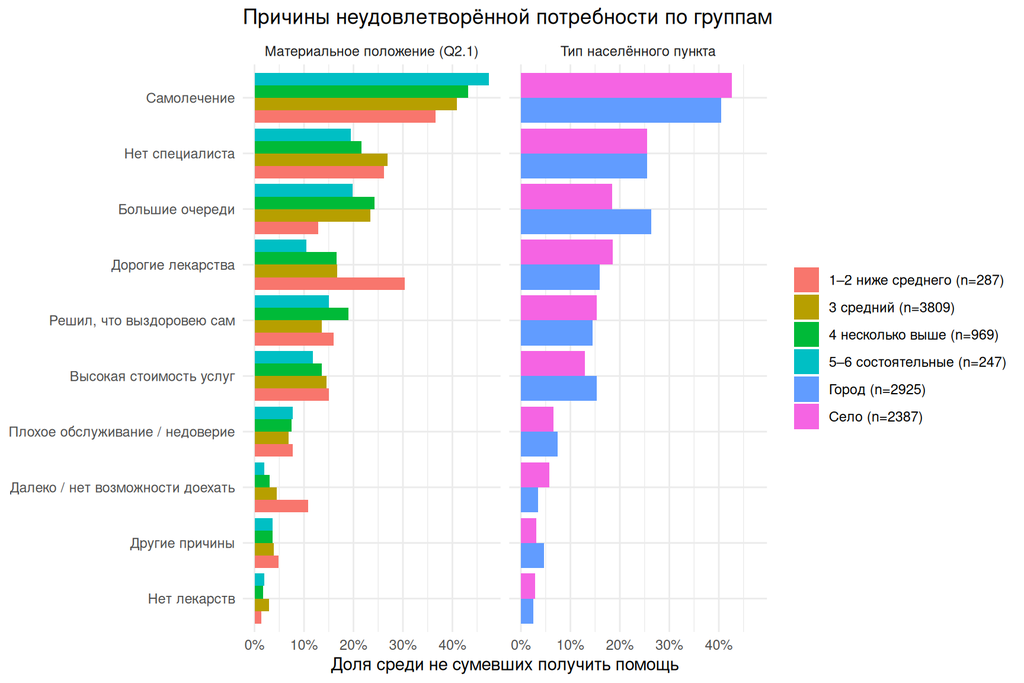

```r
map(c(area = "Тип населённого пункта", wealth = "Материальное положение (Q2.1)"), \(lbl) lbl) |>
  imap(\(lbl, v) {
    unmet_d |>
      filter(!is.na(.data[[v]])) |>
      group_by(level = .data[[v]]) |>
      summarise(across(all_of(reason_labels$r), mean), n = n(), .groups = "drop") |>
      mutate(level = as.character(level)) |>
      pivot_longer(all_of(reason_labels$r), names_to = "r", values_to = "share") |>
      mutate(dim = lbl)
  }) |>
  list_rbind() |>
  left_join(reason_labels, by = "r") |>
  mutate(level = paste0(level, " (n=", n, ")")) |>
  ggplot(aes(share, fct_reorder(reason, share), fill = level)) +
  geom_col(position = "dodge") +
  facet_wrap(~dim) +
  scale_x_continuous(labels = lab_pct) +
  labs(x = "Доля среди не сумевших получить помощь", y = NULL, fill = NULL,
       title = "Причины неудовлетворённой потребности по группам")
```

**Результат.** Структура причин в группах похожа, различия — в деталях: в городе чаще очереди (около 26% против 18% на селе), на селе чаще удалённость (около 6% против 3–4%) и дорогие лекарства. У малообеспеченных чаще дорогие лекарства (около 30%) и удалённость (около 11%), реже очереди — но в этой группе всего 287 человек, оценки неточные.

## Этап 5. Региональный анализ

Региональные показатели: текущие расходы организаций здравоохранения на душу населения (БНС, «Финансово-хозяйственная деятельность организаций здравоохранения»; в 2021 году — вместе с социальными услугами, это 4–5% суммы), врачи и средний медперсонал на 1000 населения («Талдау», данные Минздрава). Для карт берутся средние за 2022–2024 годы — годы, в которых существуют все 20 регионов.

```r
regional <- read_csv(file.path("Data", "health_regions.csv"),
                     col_types = cols(TE = col_character(), region = col_character(),
                                      .default = col_double())) |>
  transmute(year, TE, exp_pc_thousand = health_exp_pc / 1000,
            doctors_per1000 = doctors_per10k / 10, nurses_per1000 = nurses_per10k / 10)

region_year <- d |>
  group_by(year, TE) |>
  summarise(n = n(), mean_q = mean(q, na.rm = TRUE),
            unmet_rate = mean(unmet_yes, na.rm = TRUE), .groups = "drop") |>
  left_join(regional, by = c("year", "TE")) |>
  mutate(region = region_names[TE], capital = TE %in% capitals)

# Проверка: у каждой пары «регион × год» из опроса есть региональные показатели
stopifnot(nrow(region_year) == 17 + 20 * 3, all(!is.na(region_year$exp_pc_thousand)),
          all(!is.na(region_year$doctors_per1000)))

region_22_24 <- region_year |>
  filter(year >= 2022) |>
  group_by(TE, region, capital) |>
  summarise(across(c(mean_q, unmet_rate, exp_pc_thousand, doctors_per1000, nurses_per1000), mean),
            n = sum(n), .groups = "drop")

# Контуры регионов: OpenStreetMap (административные границы 20 регионов)
shapes <- read_csv(file.path("Data", "kz_regions_osm.csv"), col_types = cols(TE = col_character())) |>
  mutate(grp = paste(TE, part), sub = paste(TE, part, ring))
stopifnot(setequal(unique(shapes$TE), names(region_names)))

draw_map <- function(values, var, title, fill_label, fill_labels = waiver()) {
  map_data <- left_join(shapes, values, by = "TE")
  label_pos <- map_data |>
    filter(ring == 0) |>
    group_by(TE) |>
    summarise(lon = mean(range(lon)), lat = mean(range(lat)), .groups = "drop") |>
    left_join(values, by = "TE")
  ggplot(map_data, aes(lon, lat)) +
    geom_polygon(aes(group = grp, subgroup = sub, fill = .data[[var]]), colour = "white",
                 linewidth = 0.2, data = filter(map_data, !TE %in% capitals)) +
    geom_polygon(aes(group = grp, subgroup = sub, fill = .data[[var]]), colour = "black",
                 linewidth = 0.3, data = filter(map_data, TE %in% capitals)) +
    geom_text(aes(label = round(.data[[var]], 2)), data = filter(label_pos, !TE %in% capitals),
              size = 2.8) +
    scale_fill_viridis_c(labels = fill_labels) +
    coord_quickmap() +
    labs(x = NULL, y = NULL, fill = fill_label, title = title)
}
```

### Карта 1. Оценка качества медицинских услуг по регионам

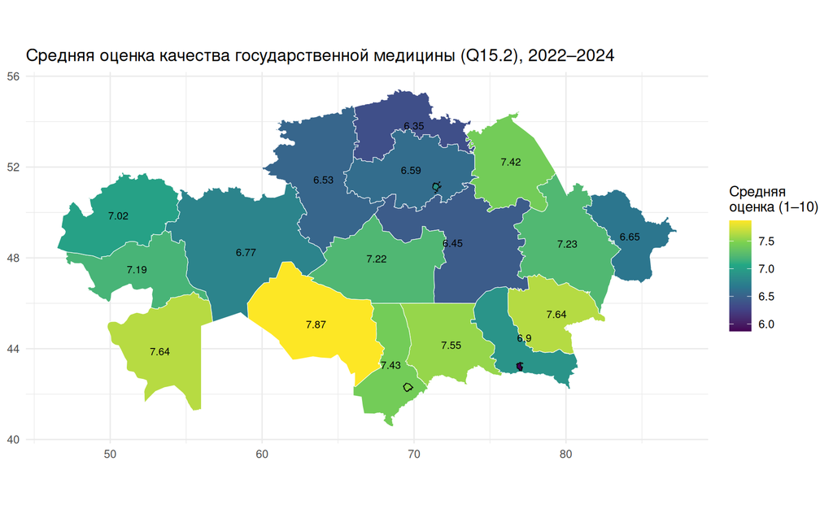

```r
draw_map(region_22_24, "mean_q",
         "Средняя оценка качества государственной медицины (Q15.2), 2022–2024",
         "Средняя\nоценка (1–10)")
```

Города республиканского значения обведены чёрным; их значения — в таблице ниже.

```r
region_22_24 |>
  arrange(mean_q) |>
  transmute(Регион = region, `Респондентов` = n, `Средняя оценка` = round(mean_q, 2),
            `P(unmet)` = percent(unmet_rate, 0.1), `Расходы, тыс. тг/чел.` = round(exp_pc_thousand),
            `Врачи на 1000` = round(doctors_per1000, 2), `Ср. медперсонал на 1000` = round(nurses_per1000, 2)) |>
  knitr::kable(caption = "Регионы, средние за 2022–2024 годы")
```

Регионы, средние за 2022–2024 годы

| Регион | Респондентов | Средняя оценка | P(unmet) | Расходы, тыс. тг/чел. | Врачи на 1000 | Ср. медперсонал на 1000 |
| --- | --- | --- | --- | --- | --- | --- |
| г. Алматы | 2138 | 5.87 | 18.4% | 271 | 6.59 | 9.08 |
| СКО | 1842 | 6.35 | 10.6% | 168 | 3.21 | 10.10 |
| Карагандинская | 1900 | 6.45 | 13.9% | 178 | 5.06 | 10.03 |
| Костанайская | 2303 | 6.53 | 8.5% | 153 | 3.01 | 8.08 |
| Акмолинская | 2273 | 6.59 | 12.4% | 142 | 2.56 | 8.06 |
| ВКО | 1441 | 6.65 | 15.9% | 185 | 4.14 | 10.85 |
| Актюбинская | 2051 | 6.77 | 7.8% | 136 | 4.88 | 10.28 |
| г. Астана | 1626 | 6.88 | 10.9% | 340 | 7.54 | 10.07 |
| Алматинская | 1320 | 6.90 | 13.1% | 95 | 2.42 | 7.16 |
| ЗКО | 1870 | 7.02 | 12.6% | 161 | 3.30 | 10.40 |
| Атырауская | 1434 | 7.19 | 16.9% | 137 | 3.06 | 9.11 |
| Ұлытау | 851 | 7.22 | 23.9% | 136 | 2.92 | 10.35 |
| Абай | 1340 | 7.23 | 13.8% | 158 | 4.46 | 11.12 |
| Павлодарская | 2358 | 7.42 | 4.0% | 177 | 4.09 | 9.30 |
| Туркестанская | 1666 | 7.43 | 14.1% | 93 | 3.08 | 10.06 |
| г. Шымкент | 1357 | 7.50 | 11.5% | 158 | 4.53 | 9.28 |
| Жамбылская | 1777 | 7.55 | 12.7% | 116 | 2.94 | 10.21 |
| Жетісу | 1161 | 7.64 | 13.0% | 133 | 2.54 | 9.51 |
| Мангистауская | 1520 | 7.64 | 13.6% | 134 | 3.27 | 9.99 |
| Кызылординская | 1618 | 7.87 | 11.2% | 158 | 3.58 | 13.38 |

**Результат.** Разброс средних оценок между регионами — от 5.87 (г. Алматы) до 7.87 (Кызылординская). Ниже среднего оценивают север и центр (СКО, Карагандинская, Костанайская, Акмолинская) и Алматы; выше — юг и запад (Кызылординская, Мангистауская, Жетісу, Жамбылская, Шымкент). Неудовлетворённая потребность меняется от 4.0% (Павлодарская) до 23.9% (Ұлытау) и с оценкой качества на карте не совпадает: Павлодарская — высокая оценка и мало проблем с доступом, Ұлытау — тоже высокая оценка, но больше всего проблем с доступом.

### Карта 2. Ресурсная обеспеченность здравоохранения

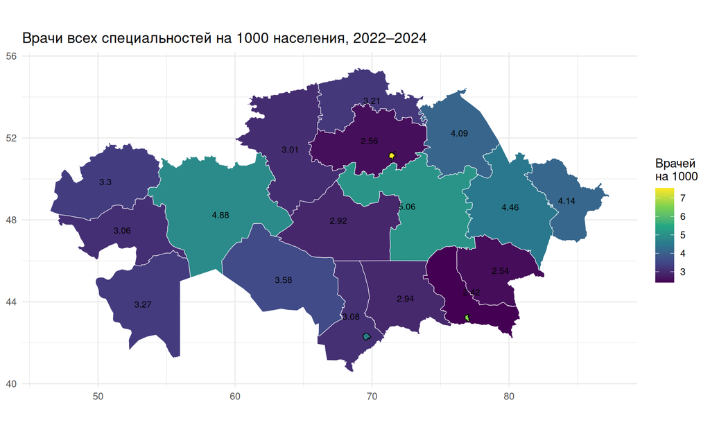

```r
draw_map(region_22_24, "doctors_per1000",
         "Врачи всех специальностей на 1000 населения, 2022–2024", "Врачей\nна 1000")
```

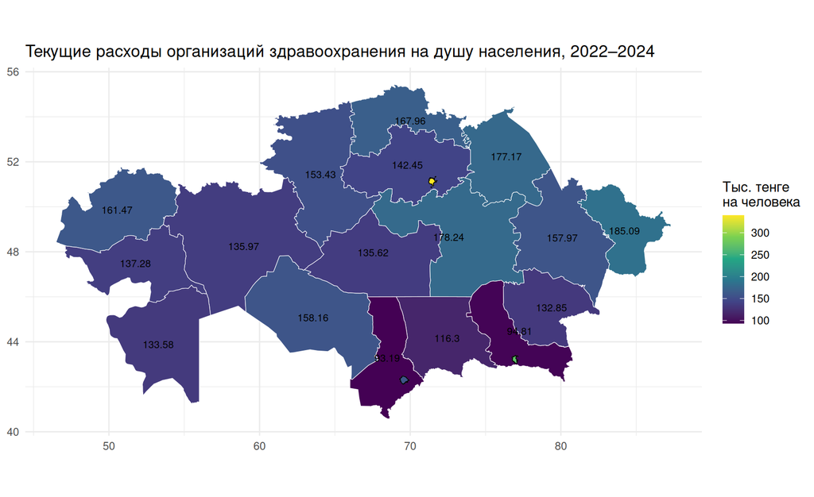

```r
draw_map(region_22_24, "exp_pc_thousand",
         "Текущие расходы организаций здравоохранения на душу населения, 2022–2024",
         "Тыс. тенге\nна человека")
```

**Результат.** Ресурсы здравоохранения сосредоточены в городах республиканского значения: в Астане 7.5 врача на 1000 человек и 340 тыс. тг расходов на человека, в Алматы 6.6 и 271 тыс. В областях — 2.4–5.1 врача и 93–185 тыс. тг. Меньше всего врачей в Алматинской, Жетісу и Акмолинской областях (2.4–2.6 на 1000), расходов — в Туркестанской и Алматинской (около 95 тыс. тг).